# Data Preparation

### General Information

This report is intended to help prepare your data. Additional fuctions for preparation are the following:

- p.numeric(dta): Lists numeric variables.
- p.continuous(dta, max_levels): Lists numeric continuous variables. Default for max_levels is .1 which restricts to numeric variables with 10% or more unique values.
- p.discrete(dta, max_levels): Lists numeric discrete variables. Default for max_levels is .1 which restricts to numeric variables with less than 10% unique values.
- p.integer(dta): Lists integer variables.
- p.character(dta): Lists character variables.
- p.unique(dta): Lists variables where every value is unique.
- p.factor(dta): Lists factor variables.
- p.asFactor(dta, columns): Converts variables to factors. Default for columns is any numeric discrete variables.
- p.replaceNull(dta, columns, null_value): Replaces null values for factor variables. The default null_value is “Missing”. Good to use in combination with p.factor().
- p.removeVariables(dta, columns): Removes variables from data set. Good to use in combination with p.unique().

#### Top row & bottom row sample of data

```r
head(data)
```

```
##   id  timestamp full_sq life_sq floor max_floor material build_year
## 1  1 2011-08-20      43      27     4        NA       NA         NA
## 2  2 2011-08-23      34      19     3        NA       NA         NA
## 3  3 2011-08-27      43      29     2        NA       NA         NA
##   num_room kitch_sq state product_type          sub_area   area_m
## 1       NA       NA    NA   Investment          Bibirevo  6407578
## 2       NA       NA    NA   Investment Nagatinskij Zaton  9589337
## 3       NA       NA    NA   Investment    Tekstil'shhiki  4808270
##   raion_popul green_zone_part  indust_part children_preschool
## 1      155572     0.189727117 0.0000699893               9576
## 2      115352     0.372602044 0.0496372570               6880
## 3      101708     0.112559644 0.1185373850               5879
##   preschool_quota preschool_education_centers_raion children_school
## 1            5001                                 5           10309
## 2            3119                                 5            7759
```

[output cut: 330 more lines]

```r
tail(data)
```

```
##          id  timestamp full_sq life_sq floor max_floor material build_year
## 30466 30468 2015-06-30      52      NA    13        17        1         NA
## 30467 30469 2015-06-30      44      27     7         9        1       1975
## 30468 30470 2015-06-30      86      59     3         9        2       1935
##       num_room kitch_sq state  product_type             sub_area   area_m
## 30466        2        1     1 OwnerOccupier             Tverskoe  7307411
## 30467        2        6     3    Investment             Otradnoe 10053052
## 30468        4       10     3    Investment             Tverskoe  7307411
##       raion_popul green_zone_part  indust_part children_preschool
## 30466       75377      0.06544431 0.0000781528               4237
## 30467      175518      0.09627020 0.3003225180               9753
## 30468       75377      0.06544431 0.0000781528               4237
##       preschool_quota preschool_education_centers_raion children_school
## 30466            1874                                 4            6398
## 30467            5088                                 4           10311
```

[output cut: 358 more lines]

#### Data Structure

```r
str(data)
```

```
## 'data.frame':    30471 obs. of  292 variables:
##  $ id                                   : int  1 2 3 4 5 6 7 8 9 10 ...
##  $ timestamp                            : Factor w/ 1161 levels "2011-08-20","2011-08-23",..: 1 2 3 4 5 6 7 8 9 10 ...
##  $ full_sq                              : int  43 34 43 89 77 67 25 44 42 36 ...
##  $ life_sq                              : int  27 19 29 50 77 46 14 44 27 21 ...
##  $ floor                                : int  4 3 2 9 4 14 10 5 5 9 ...
##  $ max_floor                            : int  NA NA NA NA NA NA NA NA NA NA ...
##  $ material                             : int  NA NA NA NA NA NA NA NA NA NA ...
##  $ build_year                           : int  NA NA NA NA NA NA NA NA NA NA ...
##  $ num_room                             : int  NA NA NA NA NA NA NA NA NA NA ...
##  $ kitch_sq                             : int  NA NA NA NA NA NA NA NA NA NA ...
##  $ state                                : int  NA NA NA NA NA NA NA NA NA NA ...
##  $ product_type                         : Factor w/ 2 levels "Investment","OwnerOccupier": 1 1 1 1 1 1 1 1 1 1 ...
##  $ sub_area                             : Factor w/ 146 levels "Ajeroport","Akademicheskoe",..: 10 71 130 66 7 74 123 10 45 51 ...
##  $ area_m                               : num  6407578 9589337 4808270 12583536 8398461 ...
```

[output cut: 86 more lines]

#### Data Summary

Builds off of the describe() function.

```r
p.summary(data) #* represents factor variables.
```

```
##                                       vars     n distn distperc nulln
## id                                       1 30471 30471    1.000     0
## timestamp*                               2 30471  1161    0.038     0
## full_sq                                  3 30471   211    0.007     0
## life_sq                                  4 24088   176    0.006  6383
## floor                                    5 30304    42    0.001   167
## max_floor                                6 20899    50    0.002  9572
## material                                 7 20899     7    0.000  9572
## build_year                               8 16866   120    0.004 13605
## num_room                                 9 20899    14    0.000  9572
## kitch_sq                                10 20899    75    0.002  9572
## state                                   11 16912     6    0.000 13559
## product_type*                           12 30471     2    0.000     0
## sub_area*                               13 30471   146    0.005     0
## area_m                                  14 30471   146    0.005     0
## raion_popul                             15 30471   146    0.005     0
## green_zone_part                         16 30471   146    0.005     0
## indust_part                             17 30471   132    0.004     0
## children_preschool                      18 30471   146    0.005     0
## preschool_quota                         19 23783   122    0.004  6688
## preschool_education_centers_raion       20 30471    13    0.000     0
## children_school                         21 30471   146    0.005     0
## school_quota                            22 23786   126    0.004  6685
## school_education_centers_raion          23 30471    14    0.000     0
## school_education_centers_top_20_raion   24 30471     3    0.000     0
## hospital_beds_raion                     25 16030    80    0.003 14441
## healthcare_centers_raion                26 30471     7    0.000     0
## university_top_20_raion                 27 30471     4    0.000     0
## sport_objects_raion                     28 30471    24    0.001     0
## additional_education_raion              29 30471    12    0.000     0
## culture_objects_top_25*                 30 30471     2    0.000     0
## culture_objects_top_25_raion            31 30471     6    0.000     0
## shopping_centers_raion                  32 30471    16    0.001     0
## office_raion                            33 30471    30    0.001     0
## thermal_power_plant_raion*              34 30471     2    0.000     0
## incineration_raion*                     35 30471     2    0.000     0
## oil_chemistry_raion*                    36 30471     2    0.000     0
## radiation_raion*                        37 30471     2    0.000     0
## railroad_terminal_raion*                38 30471     2    0.000     0
## big_market_raion*                       39 30471     2    0.000     0
```

[output cut: 338 more lines]

```
## full_all                              1.621368e+03 30471  292
## male_f                                7.415500e+02 30471  292
## female_f                              8.801065e+02 30471  292
## young_all                             4.747928e+01 30471  292
## young_male                            2.449274e+01 30471  292
## young_female                          2.303253e+01 30471  292
## work_all                              2.147323e+02 30471  292
## work_male                             1.084969e+02 30471  292
## work_female                           1.068011e+02 30471  292
## ekder_all                             7.547412e+01 30471  292
## ekder_male                            2.333777e+01 30471  292
## ekder_female                          5.238517e+01 30471  292
## X0_6_all                              2.186433e+01 30471  292
## X0_6_male                             1.130400e+01 30471  292
##  [ reached getOption("max.print") -- omitted 237 rows ]
```

#### Data Structure (Summary of Variables)

Numeric discrete lists any numeric variables where less than 10% of their data is unique.

```r
p.structure(data)
```

```
## All Variables
##   [1] "id"
##   [2] "timestamp"
##   [3] "full_sq"
##   [4] "life_sq"
##   [5] "floor"
##   [6] "max_floor"
##   [7] "material"
##   [8] "build_year"
##   [9] "num_room"
##  [10] "kitch_sq"
##  [11] "state"
##  [12] "product_type"
##  [13] "sub_area"
##  [14] "area_m"
```

[output cut: 1032 more lines]

#### Table Summaries of Data

Table summary of all numeric discrete & factor variables with 100 or less distinct values. Builds off of the table() function. For a specific table summary of a variable use the table() function.

```r
p.table(data)
```

```
## floor
##    0    1    2    3    4    5    6    7    8    9   10   11   12   13   14
##    9 2002 2874 3028 2609 2752 1878 1966 1830 1843 1307 1262 1341  918 1001
##   15   16   17   18   19   20   21   22   23   24   25   26   27   28   29
##  747  811  795  231  212  180  138  173  125  100  104   14    7    6    3
##   30   31   32   33   34   36   37   38   41   44   77
##    6    5   14    1    3    2    2    1    1    2    1
##
## max_floor
##    0    1    2    3    4    5    6    7    8    9   10   11   12   13   14
##  550  973  100  278  278 2267  148  116  307 3025  284   54 2229   56 1362
##   15   16   17   18   19   20   21   22   23   24   25   26   27   28   29
##  239 1146 4672  195  220  204   57  745   94  396  735   10   17   10    6
##   30   31   32   33   34   36   37   38   39   40   41   42   44   45   47
##   42    3   17    3    3    2    7    1    4   25    1    1    1    2    2
##   48   57   99  117
##    7    1    3    1
##
## material
##     1     2     3     4     5     6
## 14197  2993     1  1344  1561   803
##
## num_room
##    0    1    2    3    4    5    6    7    8    9   10   17   19
##   14 7602 8132 4675  418   40    9    1    3    1    2    1    1
##
## kitch_sq
##    0    1    2    3    4    5    6    7    8    9   10   11   12   13   14
## 1381 4854   14   47   87 2594 2298 1262 2678 1806 2241  478  552  153  112
##   15   16   17   18   19   20   21   22   23   24   25   26   27   28   29
##   67   56   39   21   23   25    4    8    4    5    4    1    1    2    3
##   30   31   32   33   34   35   36   37   39   40   41   42   43   44   48
##    4    3    3    2    2    1    1    4    2    4    4    4    2    1    1
##   51   53   54   57   58   60   61   62   63   65   66   72   73   74   75
##    2    1    3    2    2    2    2    2    3    1    1    1    1    1    1
##   78   79   84   86   95   96   97  112  123  620 1970 1974 2013 2014
##    1    1    1    1    1    1    1    3    1    1    1    1    1    1
##
## state
##    1    2    3    4   33
```

[output cut: 748 more lines]

```
## 22833  3164  1175   270   329   293   122   118   114    98    69   108
##    12    13    14    15    16    17    18    19    20    21    22    23
##    86    36    45    35    59    82    84    55    70    70   123    62
##    24    25    26    27    28    29    30
##   130    69   677    34    34    26     1
##
## mosque_count_5000
##     0     1     2
## 18887  9687  1897
##
## market_count_5000
##    0    1    2    3    4    5    6    7    8    9   10   11   12   13   14
## 4103 4328 1719 1623 2134 2575 1428 1409 1156 1118 1408 1583 1820 2046  916
##   15   16   17   18   19   20   21
##  462  270  160  148   45   19    1
```

#### Missing Data

The following graphs shows the distribution of missing values.

[figure not shown]

```r
DataExplorer::PlotMissing(data)
```

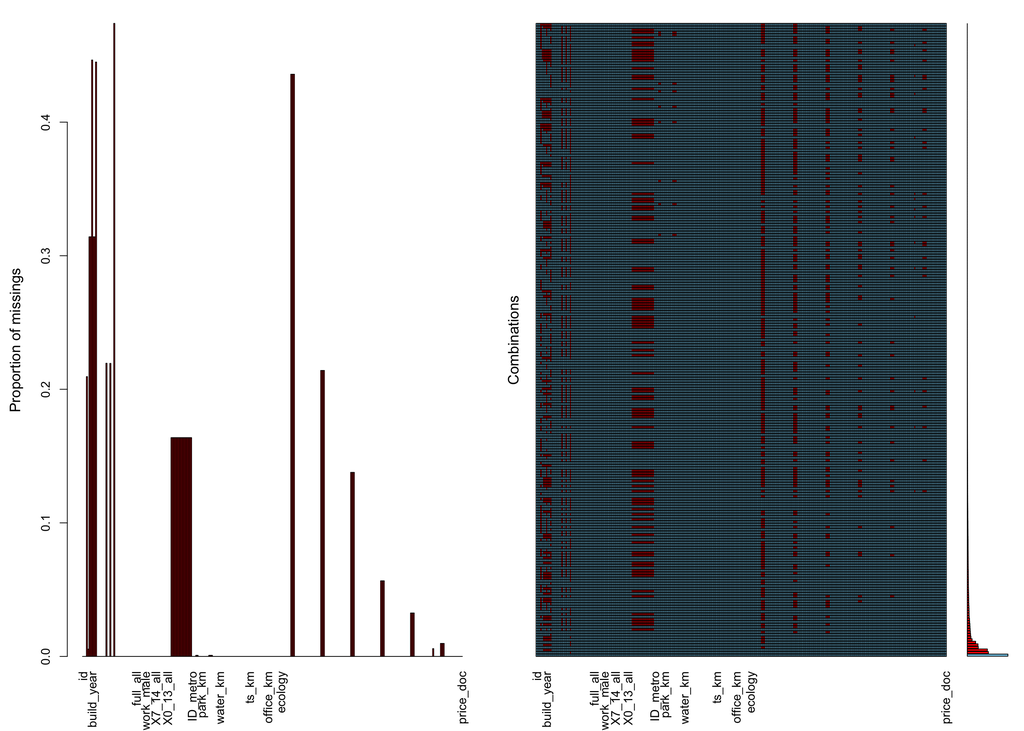

```r
VIM::aggr(data, numbers=TRUE)
```